# B64_Rotations

| Abuzer Yakaryilmaz \| April 27, 2019 (updated) |
| --- |
| This cell contains some macros. If there is a problem with displaying mathematical formulas, please run this cell to load these macros. |

$ \newcommand{\bra}[1]{\langle #1|} $ $ \newcommand{\ket}[1]{|#1\rangle} $ $ \newcommand{\braket}[2]{\langle #1|#2\rangle} $ $ \newcommand{\dot}[2]{ #1 \cdot #2} $ $ \newcommand{\biginner}[2]{\left\langle #1,#2\right\rangle} $ $ \newcommand{\mymatrix}[2]{\left( \begin{array}{#1} #2\end{array} \right)} $ $ \newcommand{\myvector}[1]{\mymatrix{c}{#1}} $ $ \newcommand{\myrvector}[1]{\mymatrix{r}{#1}} $ $ \newcommand{\mypar}[1]{\left( #1 \right)} $ $ \newcommand{\mybigpar}[1]{ \Big( #1 \Big)} $ $ \newcommand{\sqrttwo}{\frac{1}{\sqrt{2}}} $ $ \newcommand{\dsqrttwo}{\dfrac{1}{\sqrt{2}}} $ $ \newcommand{\onehalf}{\frac{1}{2}} $ $ \newcommand{\donehalf}{\dfrac{1}{2}} $ $ \newcommand{\hadamard}{ \mymatrix{rr}{ \sqrttwo & \sqrttwo \\ \sqrttwo & -\sqrttwo }} $ $ \newcommand{\vzero}{\myvector{1\\0}} $ $ \newcommand{\vone}{\myvector{0\\1}} $ $ \newcommand{\vhadamardzero}{\myvector{ \sqrttwo \\ \sqrttwo } } $ $ \newcommand{\vhadamardone}{ \myrvector{ \sqrttwo \\ -\sqrttwo } } $ $ \newcommand{\myarray}[2]{ \begin{array}{#1}#2\end{array}} $ $ \newcommand{\X}{ \mymatrix{cc}{0 & 1 \\ 1 & 0} } $ $ \newcommand{\Z}{ \mymatrix{rr}{1 & 0 \\ 0 & -1} } $ $ \newcommand{\Htwo}{ \mymatrix{rrrr}{ \frac{1}{2} & \frac{1}{2} & \frac{1}{2} & \frac{1}{2} \\ \frac{1}{2} & -\frac{1}{2} & \frac{1}{2} & -\frac{1}{2} \\ \frac{1}{2} & \frac{1}{2} & -\frac{1}{2} & -\frac{1}{2} \\ \frac{1}{2} & -\frac{1}{2} & -\frac{1}{2} & \frac{1}{2} } } $ $ \newcommand{\CNOT}{ \mymatrix{cccc}{1 & 0 & 0 & 0 \\ 0 & 1 & 0 & 0 \\ 0 & 0 & 0 & 1 \\ 0 & 0 & 1 & 0} } $ $ \newcommand{\norm}[1]{ \left\lVert #1 \right\rVert } $

## Rotations

| *We use certain tools from python library "**matplotlib.pyplot**" for drawing. Check the notebook "Python: Drawing" for the list of these tools.* |
| --- |

We start with drawing the quantum states $ \ket{0} $ and $ \ket{+} = \myvector{ \frac{1}{\sqrt{2}} \\ \frac{1}{\sqrt{2}} } $.

Our predefined function "draw_qubit()" draws a figure, the origin, the axes, the unit circle, and base quantum states.  
Our predefined function "draw_quantum_state(x,y,name)" draws an arrow from (0,0) to (x,y) and associates it with name.  
We include our predefined functions with the following line of code:

```
%run qlatvia.py
```

```python
%run qlatvia.py

draw_qubit()

sqrttwo=2**0.5

draw_quantum_state(1,0,"")

draw_quantum_state(1/sqrttwo,1/sqrttwo,"|+>")

# drawing the angle with |0>-axis
from matplotlib.pyplot import gca, text
from matplotlib.patches import Arc
gca().add_patch( Arc((0,0),0.4,0.4,angle=0,theta1=0,theta2=45) )
text(0.08,0.05,'.',fontsize=30)
text(0.21,0.09,'\u03C0/4')
```

### Task 1 (Discussion)

Suppose that we start in state $ \ket{0} $, and then obtain state $\ket{+}$ by appling a rotation operator.

If we apply the same operator consequtively, what can be the new quantum state?

Here are eight candidates:

$$ \myarray{|c|c|c|c|}{ \hline A & \ket{0} = \vzero & E & \ket{+} = \myrvector{\sqrttwo \\ \sqrttwo} \\ \hline B & \ket{1} = \vone & F & \ket{-} = \myrvector{\sqrttwo \\ -\sqrttwo} \\ \hline C & -\ket{0} = \myrvector{-1 \\ 0} & G & -\ket{+} = \myrvector{-\sqrttwo \\ -\sqrttwo} \\ \hline D & -\ket{1} = \myrvector{0 \\ -1} & H & -\ket{-} = \myrvector{-\sqrttwo \\ \sqrttwo} \\ \hline } $$

### Rotation with degree $\pi/4$

Its matrix form is similar to Hadamard operator:

$$ R(\pi/4) = \mymatrix{rr}{\cos(\pi/4) & -\sin(\pi/4) \\ \sin(\pi/4) & \cos(\pi/4) } = \mymatrix{rr}{ \sqrttwo & -\sqrttwo \\ \sqrttwo & \sqrttwo} $$

.

### Task 2

Start with state $ \ket{0} $.

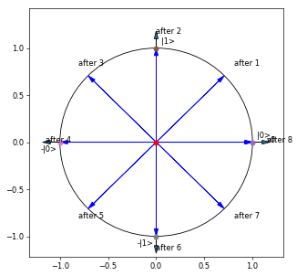

```python
%run qlatvia.py

draw_qubit()

[x,y]=[1,0]

draw_quantum_state(x,y,"v0")

sqrttwo = 2**0.5
oversqrttwo = 1/sqrttwo

R = [ [oversqrttwo, -1*oversqrttwo], [oversqrttwo,oversqrttwo] ]

#
# your code is here
#
#
import numpy as np
R = np.array(R)
# initial state 0
s0  = np.array([x, y])

for i in range(1, 9):
    # rotate the matrix
    s0 = np.matmul(R, s0)
    # draw the matrix
    draw_quantum_state(s0[0], s0[1], "after " + str(i))
```

click for our solution

### Rotation with degree $\theta$

The matrix form of a rotation is as follows:

$$ R(\theta) = \mymatrix{rr}{\cos(\theta) & -\sin(\theta) \\ \sin(\theta) & \cos(\theta) }, $$

where $ \theta $ is the angle of rotation (in counter-clockwise direction).

In qiskit, ry-gate can be used for rotation in 2-dimensional real-valued plane.

### Technical remark

Even though, we focus on only real-valued quantum systems in this tutorial, the quatum state of a qubit is represented by 2-dimensional complex-valued vector in general. To visually represent a complex number, we use two dimensions. So, to visually represent the state of a qubit, we use four dimensions.

On the other hand, we can still visualize any state of a qubit by using certain mapping from four dimensions to three dimensions. This representation is called as Bloch sphere.

The rotation operators over a single (complex-valued) qubit are defined on Bloch sphere. The names of gates "x", "y", or "z" refer to the axes on Bloch sphere. When we focus on real-valued qubit, then we should be careful about the parameter(s) that a gate takes.

*In qiskit, ry-gate makes a rotation around $y$-axis with the given angle, say $\theta$, on Bloch sphere. This refers to a rotation in our real-valued $\ket{0}$-$\ket{1}$ plane with angle $ \frac{\theta}{2} $. Therefore, **we should provide the twice of the desired angle in this tutorial.***

### Rotations with ry-gate

The ry-gate is used for rotation in 2-dimensional real-valued plane.

If our angle is $ \theta $ radians, then we pass $ 2 \theta $ radians as the parameter to ry-gate.

Then ry-gate implements the rotation with angle $\theta$.

The default direction of a rotation by ry-gate is counterclockwise.

```
mycircuit.ry(angle_of_rotation,quantum_register)
```

### Example

We implement the rotation with angle $ \pi/4 $ in qiskit.

We start with state $\ket{0}$, and apply ry-gate 8 times.

After each iteration, **we read the quantum state from the local simulator**, and then draw it.

```
iteration 1 : the quantum state is [0.70710678+0.j 0.70710678+0.j]
iteration 2 : the quantum state is [0.+0.j 1.+0.j]
iteration 3 : the quantum state is [-0.70710678+0.j  0.70710678+0.j]
iteration 4 : the quantum state is [-1.+0.j  0.+0.j]
iteration 5 : the quantum state is [-0.70710678+0.j -0.70710678+0.j]
iteration 6 : the quantum state is [ 0.+0.j -1.+0.j]
iteration 7 : the quantum state is [ 0.70710678+0.j -0.70710678+0.j]
iteration 8 : the quantum state is [1.+0.j 0.+0.j]
```

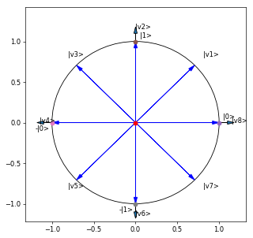

```python
%run qlatvia.py

draw_qubit()

from qiskit import QuantumRegister, ClassicalRegister, QuantumCircuit, execute, Aer
from math import pi

# we define a quantum circuit with one qubit and one bit
qreg1 =  QuantumRegister(1) # quantum register with a single qubit
creg1 = ClassicalRegister(1) # classical register with a single bit
mycircuit1 = QuantumCircuit(qreg1,creg1) # quantum circuit with quantum and classical registers

rotation_angle = pi/4

for i in range(1,9):
    mycircuit1.ry(2*rotation_angle,qreg1[0])
     # the following code is used to get the quantum state of the quantum register
    job = execute(mycircuit1,Aer.get_backend('statevector_simulator'))
    current_quantum_state=job.result().get_statevector(mycircuit1)
    print("iteration",i,": the quantum state is",current_quantum_state)
    x_value = current_quantum_state[0].real # get the amplitude of |0>
    y_value = current_quantum_state[1].real # get the amplitude of |1>
    draw_quantum_state(x_value,y_value,"|v"+str(i)+">")
```

### Task 3

Repeat the same example 12 times for angle $ \pi/6 $.

Repeat the same example 16 times for angle $ 3\pi/8 $.

Repeat the same example 20 times for angle $ \sqrt{2}\pi $.

```
iteration 1 : the quantum state is [0.8660254+0.j 0.5      +0.j]
iteration 2 : the quantum state is [0.5      +0.j 0.8660254+0.j]
iteration 3 : the quantum state is [0.+0.j 1.+0.j]
iteration 4 : the quantum state is [-0.5      +0.j  0.8660254+0.j]
iteration 5 : the quantum state is [-0.8660254+0.j  0.5      +0.j]
iteration 6 : the quantum state is [-1.+0.j  0.+0.j]
iteration 7 : the quantum state is [-0.8660254+0.j -0.5      +0.j]
iteration 8 : the quantum state is [-0.5      +0.j -0.8660254+0.j]
iteration 9 : the quantum state is [ 0.+0.j -1.+0.j]
iteration 10 : the quantum state is [ 0.5      +0.j -0.8660254+0.j]
iteration 11 : the quantum state is [ 0.8660254+0.j -0.5      +0.j]
```

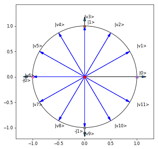

```python
#
# your code is here
#
import math

%run qlatvia.py


def rotate_angle_times(angle, times):
    draw_qubit()
    qreg1 =  QuantumRegister(1) # quantum register with a single qubit
    creg1 = ClassicalRegister(1) # classical register with a single bit
    mycircuit1 = QuantumCircuit(qreg1,creg1) # quantum circuit with quantum and classical registers
    rotation_angle = angle

    for i in range(1,times):
        # defined for block sphere
        mycircuit1.ry(2*rotation_angle,qreg1[0])
         # simulator gives the states
        job = execute(mycircuit1,Aer.get_backend('statevector_simulator'))
        current_quantum_state = job.result().get_statevector(mycircuit1)
        print("iteration",i,": the quantum state is",current_quantum_state)
        x_value = current_quantum_state[0].real # get the amplitude of |0>
        y_value = current_quantum_state[1].real # get the amplitude of |1>
        draw_quantum_state(x_value,y_value,"|v"+str(i)+">")

rotate_angle_times((math.pi / 6), 12)
```

```
iteration 1 : the quantum state is [0.38268343+0.j 0.92387953+0.j]
iteration 2 : the quantum state is [-0.70710678+0.j  0.70710678+0.j]
iteration 3 : the quantum state is [-0.92387953+0.j -0.38268343+0.j]
iteration 4 : the quantum state is [ 0.+0.j -1.+0.j]
iteration 5 : the quantum state is [ 0.92387953+0.j -0.38268343+0.j]
iteration 6 : the quantum state is [0.70710678+0.j 0.70710678+0.j]
iteration 7 : the quantum state is [-0.38268343+0.j  0.92387953+0.j]
iteration 8 : the quantum state is [-1.+0.j  0.+0.j]
iteration 9 : the quantum state is [-0.38268343+0.j -0.92387953+0.j]
iteration 10 : the quantum state is [ 0.70710678+0.j -0.70710678+0.j]
iteration 11 : the quantum state is [0.92387953+0.j 0.38268343+0.j]
iteration 12 : the quantum state is [0.+0.j 1.+0.j]
iteration 13 : the quantum state is [-0.92387953+0.j  0.38268343+0.j]
iteration 14 : the quantum state is [-0.70710678+0.j -0.70710678+0.j]
iteration 15 : the quantum state is [ 0.38268343+0.j -0.92387953+0.j]
```

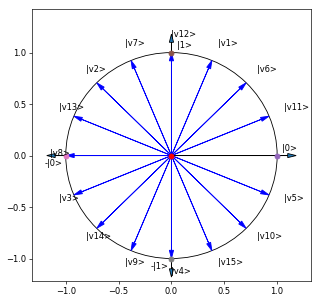

```python
rotate_angle_times(((3 * math.pi) / 8), 16)
```

```
iteration 1 : the quantum state is [-0.26625534+0.j -0.96390253+0.j]
iteration 2 : the quantum state is [-0.85821619+0.j  0.5132884 +0.j]
iteration 3 : the quantum state is [0.72326463+0.j 0.69057098+0.j]
iteration 4 : the quantum state is [ 0.47307004+0.j -0.88102482+0.j]
iteration 5 : the quantum state is [-0.97517948+0.j -0.22141585+0.j]
iteration 6 : the quantum state is [0.04622345+0.j 0.99893113+0.j]
iteration 7 : the quantum state is [ 0.950565  +0.j -0.31052565+0.j]
iteration 8 : the quantum state is [-0.55240947+0.j -0.8335729 +0.j]
iteration 9 : the quantum state is [-0.65640106+0.j  0.75441212+0.j]
iteration 10 : the quantum state is [0.90195005+0.j 0.43184038+0.j]
iteration 11 : the quantum state is [ 0.17610302+0.j -0.98437174+0.j]
iteration 12 : the quantum state is [-0.99572679+0.j  0.09234809+0.j]
iteration 13 : the quantum state is [0.35413213+0.j 0.9351954 +0.j]
iteration 14 : the quantum state is [ 0.80714764+0.j -0.59034963+0.j]
iteration 15 : the quantum state is [-0.78394687+0.j -0.62082791+0.j]
iteration 16 : the quantum state is [-0.38968756+0.j  0.92094713+0.j]
iteration 17 : the quantum state is [0.99145966+0.j 0.13041373+0.j]
iteration 18 : the quantum state is [-0.13827531+0.j -0.99039383+0.j]
iteration 19 : the quantum state is [-0.91782658+0.j  0.39698157+0.j]
```

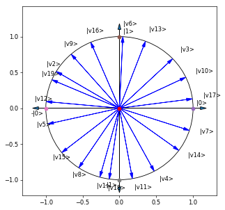

```python
rotate_angle_times(((2**(0.5)) * math.pi ), 20)
```

### Task 4

Create three separate qubits (i.e., different circuits).

Randomly pick an angle $ \theta $.

Rotate the first qubit with angle $ \theta $.

Rotate the second and third qubits with angles $\theta_1$ and $ \theta_2 $ such that both states are different but orthogonal to the state of the first qubit.

Read the states of three qubits from the local simulator, say $ \ket{v_0} $, $ \ket{v_1} $, and $ \ket{v_2} $, respectively.

Verify the following by drawing or by finding their dot products:

1. $ \ket{v_0} $ and $ \ket{v_1} $ are orthogonal (i.e., their dot product is zero.)
2. $ \ket{v_0} $ and $ \ket{v_2} $ are orthogonal
3. $ \ket{v_1} = -1\ket{v_2} $ (i.e., their dot product is -1).

**The orthogonal states can be separated exactly.**

Rotate all three qubits with an angle $\theta'$ such that we observe only state $ \ket{0} $ in the first qubit and state $ \ket{1} $ in the second and third qubits (or vice versa).

*Remark that, after picking $\theta$, you determine $\theta_1$, $ \theta_2 $, and $ \theta' $.*

Measure each qubit.

Execute your program 1000 times.

```python
#
# your code is here
#
from qiskit import QuantumRegister, ClassicalRegister, QuantumCircuit, execute, Aer
from math import pi
from random import randrange

# first qubit
qreg1 =  QuantumRegister(1)
creg1 = ClassicalRegister(1)
mycircuit1 = QuantumCircuit(qreg1,creg1)

# second qubit
qreg2 =  QuantumRegister(1)
creg2 = ClassicalRegister(1)
mycircuit2 = QuantumCircuit(qreg2,creg2)

# third qubit
qreg3 =  QuantumRegister(1)
creg3 = ClassicalRegister(1)
mycircuit3 = QuantumCircuit(qreg3,creg3)

# randomly pick the angle of rotation
r = randrange(100)
theta = 2*pi*(r/100) # radians
print("the picked angle is",r*3.6,"degrees and",theta,"radians")


# rotate the first qubit
mycircuit1.ry(2*theta,qreg1[0])

# the different angles orthogonal to theta
theta1 = theta + pi/2
theta2 = theta - pi/2

# rotate the second and third qubits
mycircuit2.ry(2*theta1,qreg2[0])
mycircuit3.ry(2*theta2,qreg3[0])
```

```
the picked angle is 108.0 degrees and 1.8849555921538759 radians
```

```
<qiskit.extensions.standard.ry.RYGate at 0x1250d0080>
```

```python
# read the quantum state of the first qubit
job = execute(mycircuit1,Aer.get_backend('statevector_simulator'))
current_quantum_state=job.result().get_statevector(mycircuit1)
[x1,y1]=[current_quantum_state[0].real,current_quantum_state[1].real]
print("the first qubit:",x1,y1)

# read the quantum state of the second qubit
job = execute(mycircuit2,Aer.get_backend('statevector_simulator'))
current_quantum_state=job.result().get_statevector(mycircuit2)
[x2,y2]=[current_quantum_state[0].real,current_quantum_state[1].real]
print("the second qubit:",x2,y2)

# read the quantum state of the third qubit
job = execute(mycircuit3,Aer.get_backend('statevector_simulator'))
current_quantum_state=job.result().get_statevector(mycircuit3)
[x3,y3]=[current_quantum_state[0].real,current_quantum_state[1].real]
print("the third qubit:",x3,y3)
```

```
the first qubit: -0.30901699437494734 0.9510565162951536
the second qubit: -0.9510565162951536 -0.3090169943749473
the third qubit: 0.9510565162951535 0.3090169943749474
```

```python
%run qlatvia.py

draw_qubit()

draw_quantum_state(x1,y1,"v0")
draw_quantum_state(x2,y2,"v1")
draw_quantum_state(x3,y3,"v2")
```

```python
print("the dot product of |v0> and |v1> is",x1*x2+y1*y2)
print("the dot product of |v0> and |v2> is",x1*x3+y1*y3)
print("the dot product of |v1> and |v2> is",x2*x3+y2*y3)
```

```
the dot product of |v0> and |v1> is 5.551115123125783e-17
the dot product of |v0> and |v2> is 1.1102230246251565e-16
the dot product of |v1> and |v2> is -1.0
```

```python
# make a full rotation by theta + theta_prime
theta_prime = 2*pi - theta

# rotate all qubits with theta_prime
mycircuit1.ry(2*theta_prime,qreg1[0])
mycircuit2.ry(2*theta_prime,qreg2[0])
mycircuit3.ry(2*theta_prime,qreg3[0])

# measure all qubits
mycircuit1.measure(qreg1,creg1)
mycircuit2.measure(qreg2,creg2)
mycircuit3.measure(qreg3,creg3)
```

```
<qiskit.circuit.instructionset.InstructionSet at 0x12820b208>
```

```python
# draw the first circuit
mycircuit1.draw()
```

```
         ┌────────────┐┌────────────┐┌─┐┌────────────┐┌─┐
q0_0: |0>┤ Ry(3.7699) ├┤ Ry(8.7965) ├┤M├┤ Ry(8.7965) ├┤M├
         └────────────┘└────────────┘└╥┘└────────────┘└╥┘
 c0_0: 0 ═════════════════════════════╩════════════════╩═
```

```python
# draw the first circuit
mycircuit2.draw()
```

```
         ┌────────────┐┌────────────┐┌─┐┌────────────┐┌─┐
q1_0: |0>┤ Ry(6.9115) ├┤ Ry(8.7965) ├┤M├┤ Ry(8.7965) ├┤M├
         └────────────┘└────────────┘└╥┘└────────────┘└╥┘
 c1_0: 0 ═════════════════════════════╩════════════════╩═
```

```python
# draw the first circuit
mycircuit3.draw()
```

```
         ┌─────────────┐┌────────────┐┌─┐┌────────────┐┌─┐
q2_0: |0>┤ Ry(0.62832) ├┤ Ry(8.7965) ├┤M├┤ Ry(8.7965) ├┤M├
         └─────────────┘└────────────┘└╥┘└────────────┘└╥┘
 c2_0: 0 ══════════════════════════════╩════════════════╩═
```

```python
# execute the first circuit
job = execute(mycircuit1,Aer.get_backend('qasm_simulator'),shots=1000)
counts = job.result().get_counts(mycircuit1)
print(counts)

# execute the second circuit
job = execute(mycircuit2,Aer.get_backend('qasm_simulator'),shots=1000)
counts = job.result().get_counts(mycircuit2)
print(counts)

# execute the third circuit
job = execute(mycircuit3,Aer.get_backend('qasm_simulator'),shots=1000)
counts = job.result().get_counts(mycircuit3)
print(counts)
```

```
{'1': 902, '0': 98}
{'1': 102, '0': 898}
{'1': 85, '0': 915}
```

click for our solution

### Unitary backend

Unitary_simulator gives a unitary representation of all gates in the circuit until this point.

```
job = execute(circuit, Aer.get_backend('unitary_simulator'))
current_unitary = job.result().get_unitary(circuit, decimals=3)
print(current_unitary)
```

### Task 5

Create a quantum circuit with one qubit and one bit.

Rotate the qubit with angle $ \pi/4 $ eight times.

After each rotation, print the unitary operator representing the whole rotations until this point.

Verify your results by printing the rotation matrix in python.

```python
#
# your code is here
#
from qiskit import QuantumRegister, ClassicalRegister, QuantumCircuit, execute, Aer
from math import pi, cos, sin

# first qubit
qreg =  QuantumRegister(1)
creg = ClassicalRegister(1)
mycircuit = QuantumCircuit(qreg,creg)

theta=pi/4

for i in range(1,9):
    total_theta = i*theta
    mycircuit.ry(2*theta,qreg[0])
    job = execute(mycircuit, Aer.get_backend('unitary_simulator'))
    current_unitary = job.result().get_unitary(mycircuit, decimals=3)
    print("after",i,"iteration(s):")
    print(current_unitary[0][0].real,current_unitary[0][1].real)
    print(current_unitary[1][0].real,current_unitary[1][1].real)
    print("calculated by python:")
    print(round(cos(total_theta),3),round(-sin(total_theta),3))
    print(round(sin(total_theta),3),round(cos(total_theta),3))
    print()
```

```
after 1 iteration(s):
0.707 -0.707
0.707 0.707
calculated by python:
0.707 -0.707
0.707 0.707

after 2 iteration(s):
0.0 -1.0
1.0 0.0
calculated by python:
0.0 -1.0
1.0 0.0

after 3 iteration(s):
-0.707 -0.707
0.707 -0.707
calculated by python:
-0.707 -0.707
0.707 -0.707

after 4 iteration(s):
-1.0 0.0
0.0 -1.0
calculated by python:
-1.0 -0.0
0.0 -1.0

after 5 iteration(s):
-0.707 0.707
-0.707 -0.707
calculated by python:
-0.707 0.707
-0.707 -0.707

after 6 iteration(s):
0.0 1.0
-1.0 0.0
calculated by python:
-0.0 1.0
-1.0 -0.0

after 7 iteration(s):
0.707 0.707
-0.707 0.707
calculated by python:
0.707 0.707
-0.707 0.707

after 8 iteration(s):
1.0 0.0
0.0 1.0
calculated by python:
1.0 0.0
-0.0 1.0
```

click for our solution